# C:\Users\manis\Desktop\Final_Project_DSEM\Dino_Pro

# Super Raids by Puneri Paltan

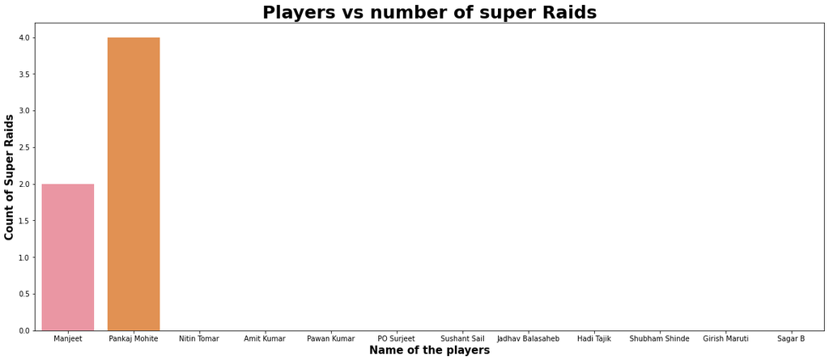

```python
plt.figure(figsize=(20,8))
sns.barplot(x=b.Name , y= b.Super_raids,data=b)

plt.xlabel("Name of the players",  fontsize = '15',fontweight = 'bold')
plt.ylabel("Count of Super Raids", fontsize = '15', fontweight = 'bold')
plt.title("Players vs number of super Raids", fontsize = '25', fontweight = 'bold')
```

### Relationship between height, weight and Points of the players

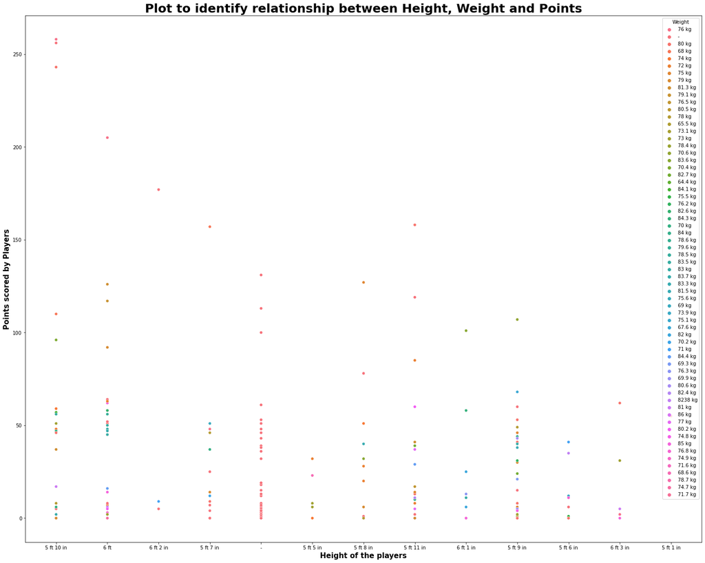

```python
plt.figure(figsize=(25,20))
sns.scatterplot(x=players_data.Height,y=players_data.Points,data=players_data,hue=players_data.Weight)


plt.xlabel("Height of the players",  fontsize = '15',fontweight = 'bold')
plt.ylabel("Points scored by Players", fontsize = '15', fontweight = 'bold')
plt.title("Plot to identify relationship between Height, Weight and Points", fontsize = '25', fontweight = 'bold')
```

[figure not shown]

#### Here from the above plot we can observe that there is no relationship between height,weight and points of the players.

## And from the above plots, it is clear there are **more agile players** in Bengal Warriors and they are scoring good amount of points by Super Raids compared to Puneri Paltan

### Top Players Of the season (Raiders, All-rounders, Defenders)

# Raiders

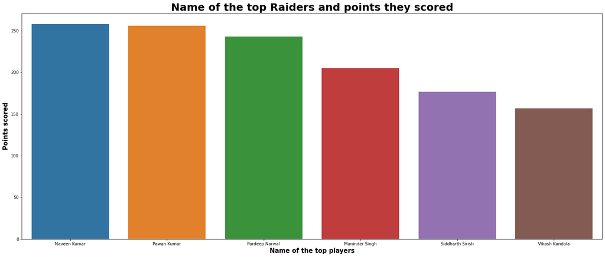

```python
Raiders=players_data[players_data.Position=='Raider']
Raider_data=Raiders[Raiders.Points>150]
plt.figure(figsize=(25,10))

sns.barplot(x=Raider_data.Name, y=Raider_data.Points, data=Raider_data)

plt.xlabel("Name of the top players",  fontsize = '15',fontweight = 'bold')
plt.ylabel("Points scored", fontsize = '15', fontweight = 'bold')
plt.title("Name of the top Raiders and points they scored", fontsize = '25', fontweight = 'bold')
```

One of the top raiders is from **Bengal Warriors - Mr Maninder Singh**, and none from Puneri Paltan

## All-Rounders

```python
def M(J):
    if (J == 'All Rounder'):
        return 'AR'
    else:
        return J
players_data['Players_Category'] = players_data.Position.map(M)
```

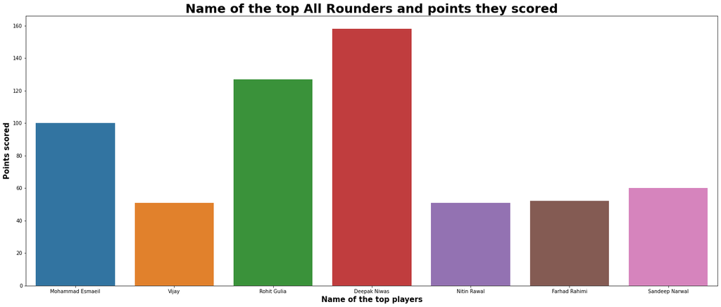

```python
AR = players_data[players_data.Players_Category =='AR']
AR_data = AR[AR.Points > 50]
plt.figure(figsize=(25,10))

sns.barplot(x=AR_data.Name,y=AR_data.Points,data=AR_data)

plt.xlabel("Name of the top players",  fontsize = '15',fontweight = 'bold')
plt.ylabel("Points scored", fontsize = '15', fontweight = 'bold')
plt.title("Name of the top All Rounders and points they scored", fontsize = '25', fontweight = 'bold')
```

# Defenders

Lets check the players unique Position

```python
players_data.Position.unique()
```

```
array(['Raider', 'Defender, right cover', 'Defender, right corner',
       'Defender, right and left cover', 'Defender, left cover',
       'Defender, left corner', 'Defender', 'All Rounder',
       'Defender, right and left corner'], dtype=object)
```

```python
def M(J):
    if (J == 'Defender, right cover') | (J == 'Defender, right corner')  | (J == 'Defender, right and left cover') | (J == 'Defender, left corner') | (J == 'Defender, right and left corner') | (J =='Defender') |(J == 'Defender, right corner')  | ( J== 'Defender, right and left cover') | (J == 'Defender, left cover') :
        return 'DR'
    else:
        return J
players_data['Players_Category'] = players_data.Position.map(M)
```

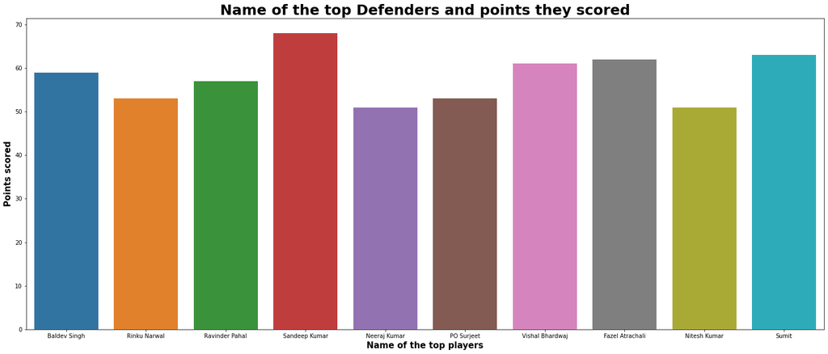

```python
DR = players_data[players_data.Players_Category =='DR']
DR_data = DR[DR.Points > 50]
plt.figure(figsize=(25,10))

sns.barplot(x=DR_data.Name,y=DR_data.Points,data=DR_data)

plt.xlabel("Name of the top players",  fontsize = '15',fontweight = 'bold')
plt.ylabel("Points scored", fontsize = '15', fontweight = 'bold')
plt.title("Name of the top Defenders and points they scored", fontsize = '25', fontweight = 'bold')
```

**Baldev Singh, Rinku Narwal** - player of **Bengal Warriors** have proved themselves as ine of the finest Defenders. And we have **PO Surjeet** from **Puneri Paltan** too who has played very well and scored points for the team

And from the above analysis it is clear that, **Bengal Warrior** has the right balance and is taking key points from all the key areas, whereas **Puneri Paltan** has to improve alot in terms of getting points through various different areas, and define a good strategy.

#### Let us predict the winnning chances of Bengal Warriors by using Logistic Regressions and the same method can be used in future to predict with all th eother teams too!

```python
from sklearn import preprocessing
label_encoder = preprocessing.LabelEncoder()
```

```python
W_Bengal_Matches_Team1['Final_Result']=label_encoder.fit_transform(W_Bengal_Matches_Team1['Final_Result'])
```

```python
W_Bengal_Matches_Team1['team1']=label_encoder.fit_transform(W_Bengal_Matches_Team1['team1'])
```

```python
W_Bengal_Matches_Team1['team2']=label_encoder.fit_transform(W_Bengal_Matches_Team1['team2'])
```

```python
x=W_Bengal_Matches_Team1.drop(['match_id','team_id','stage','team1_score','stage','series_name','team2_score','date','start_time','result','Final_Result'],axis=1)
```

```python
y=W_Bengal_Matches_Team1.Final_Result
```

```python
from sklearn.linear_model import LogisticRegression
from sklearn.model_selection import train_test_split
```

```python
X_train,X_test,y_train,y_test=train_test_split(x,y,test_size=0.2)
```

```python
model=LogisticRegression()
model.fit(X_train,y_train)
```

```
LogisticRegression()
```

```python
y_pred=model.predict(X_test)
```

```python
print("Training Accuracy :",model.score(X_train,y_train))
print("Testing Accuracy :",model.score(X_test,y_test))
```

```
Training Accuracy : 0.91
Testing Accuracy : 0.76
```

## Conclusion: Here from above Analysis, we can predict that below few Qualities one team should have to score more.

### • Quick Thinker

**Agility, presence of mind and Quick thinker are one of the main factors which contribute to overall performance of the team and As a coach we should work more or train the player so that they can be more Agile and put their best to score more which contribute the overall performance of the team!!!**

References: https://www.prokabaddi.com/

https://www.kaggle.com/datasets

https://en.wikipedia.org/wiki/Main_Page

https://towardsdatascience.com/

[figure not shown]

```python
from IPython.core.interactiveshell import InteractiveShell
InteractiveShell.ast_node_interactivity = "all"
from IPython import display
from pathlib import Path
gifPath = Path("C:/Users/manis/Downloads/thank.gif")
# Display GIF in Jupyter, CoLab, IPython
with open(gifPath,'rb') as f:
    display.Image(data=f.read(), format='png')
```